# Fifth_plot

Marcelladane

27 July 2017

**Instructions**

*Fine particulate matter (PM2.5) is an ambient air pollutant for which there is strong evidence that it is harmful to human health. In the United States, the Environmental Protection Agency (EPA) is tasked with setting national ambient air quality standards for fine PM and for tracking the emissions of this pollutant into the atmosphere. Approximatly every 3 years, the EPA releases its database on emissions of PM2.5. This database is known as the National Emissions Inventory (NEI). You can read more information about the NEI at the EPA National Emissions Inventory web site.*

For each year and for each type of PM source, the NEI records how many tons of PM2.5 were emitted from that source over the course of the entire year. The data that you will use for this assignment are for 1999, 2002, 2005, and 2008.

**PM2.5 Emissions Data structure**

The files contain the follow columns *fips*: A five-digit number (represented as a string) indicating the U.S. county *SCC*: The name of the source as indicated by a digit string (see source code classification table) *Pollutant*: A string indicating the pollutant *Emissions*: Amount of PM2.5 emitted, in tons *type*: The type of source (point, non-point, on-road, or non-road) *year*: The year of emissions recorded

**Question**

5 - How have emissions from motor vehicle sources changed from 1999–2008 in Baltimore City??

First you shall loaded some packages I might need to use Second, downloaded the data set (I called exdata) and saved on my working directory and then read 2 different tables for the SSC and NEI; SSC = Source Classification Code NEI = National Emissions Inventory

```r
packages <- c("data.table", "reshape2", "ggplot2")
sapply(packages, require, character.only = TRUE, quietly = TRUE)
```

```
## data.table   reshape2    ggplot2
##       TRUE       TRUE       TRUE
```

```r
unzip("exdata.zip")

NEI <- readRDS("summarySCC_PM25.rds")
SCC <- readRDS("Source_Classification_Code.rds")
```

Now you can create a table that is a subset (just Baltimore) and just ON_ROAD (for the motor vehicles) of the data in NEI. Then you create one new table using **aggregate**, this table will contain type, year and sum of the values of emission.

```r
sub_On_Road <- subset(NEI, fips == "24510" & type=="ON-ROAD")
head(sub_On_Road)
```

```
##         fips        SCC Pollutant Emissions    type year
## 114470 24510 220100123B  PM25-PRI      7.38 ON-ROAD 1999
## 114472 24510 220100123T  PM25-PRI      2.78 ON-ROAD 1999
## 114477 24510 220100123X  PM25-PRI     11.76 ON-ROAD 1999
## 114479 24510 220100125B  PM25-PRI      3.50 ON-ROAD 1999
## 114481 24510 220100125T  PM25-PRI      1.32 ON-ROAD 1999
## 114486 24510 220100125X  PM25-PRI      5.58 ON-ROAD 1999
```

```r
balt_On_Road <- aggregate(sub_On_Road[c("Emissions")], list(type = sub_On_Road$type, year = sub_On_Road$year), sum)
head(balt_On_Road)
```

```
##      type year Emissions
## 1 ON-ROAD 1999 346.82000
## 2 ON-ROAD 2002 134.30882
## 3 ON-ROAD 2005 130.43038
## 4 ON-ROAD 2008  88.27546
```

Finally plot the output. No specs of the type of graphic we were suppose to make I made a plot with year versus emmissions Set geom to in the line format and theme to be black and white Also added labels for the plot

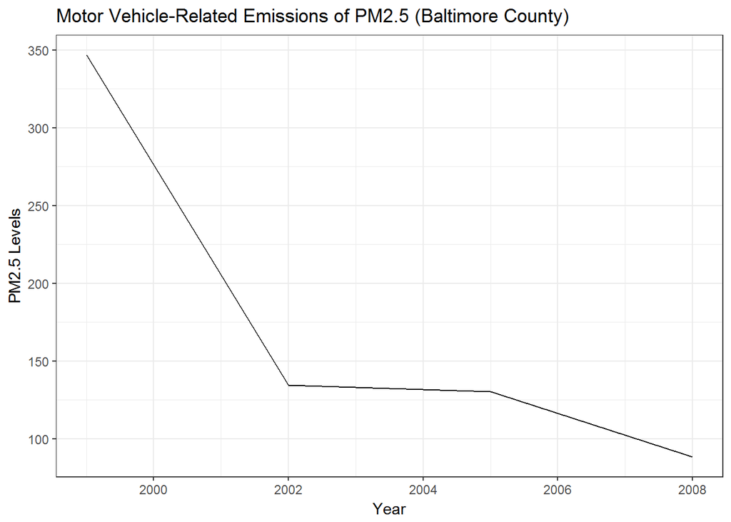

```r
qplot(year, Emissions, data = balt_On_Road, geom= "line") + theme_bw() + ggtitle("Motor Vehicle-Related Emissions of PM2.5 (Baltimore County)") + xlab("Year") + ylab("PM2.5 Levels")
```